# Logistic Regression

### Introduction

In this `jupyter notebook`, I will be fitting a `Binomial Logistic Regression` model to a dataset in order to answer these questions:

### **Question (α):**

**When ( weekday or weekend) is it more likely for a fraud to be committed?**

### **Question (β):**

**Are transactions that take more time to complete riskier to fraud?**

### Data Wrangling: Gather - Assess - Clean

To get started, I will import the libraries and take a look at the dataset.

###### Import libraries:

`numpy` (mathematical operations on arrays)  
`pandas` (data manipulation and analysis)  
`statsmodels` (statistical data exploration)  
`Image` (display images)  
`matplotlib` (library to plot graphs)

```python
import numpy as np
import pandas as pd
from IPython.display import Image
import statsmodels.api as sm
import matplotlib.pyplot as plt
%matplotlib inline
```

#### Gather

The dataset:

```python
df = pd.read_csv('./fraud_dataset.csv')
df.head()
```

|  | transaction_id | duration | day | fraud |
| --- | --- | --- | --- | --- |
| 0 | 28891 | 21.302600 | weekend | False |
| 1 | 61629 | 22.932765 | weekend | False |
| 2 | 53707 | 32.694992 | weekday | False |
| 3 | 47812 | 32.784252 | weekend | False |
| 4 | 43455 | 17.756828 | weekend | False |

### Why a `Logistic Regression` model?

The response variable is **categorical** with only two levels (fraud: True or False) and the explanatory variables are both **categorical** and **quantitative**.  
Due to the nature of the **response** variable ( **categorical**), a `logistic regression` model is required.  
If the **response** variable was **quantitative**, then a `multiple linear regression` model would be appropriate.

#### Assess

```python
df.shape
```

```
(8793, 4)
```

```python
df.sample(5)
```

|  | transaction_id | duration | day | fraud |
| --- | --- | --- | --- | --- |
| 8555 | 21160 | 24.968216 | weekend | False |
| 2232 | 70618 | 46.117161 | weekend | False |
| 2145 | 86568 | 28.642775 | weekend | False |
| 927 | 23100 | 46.209226 | weekend | False |
| 6428 | 45863 | 17.954387 | weekend | False |

```python
df.info()
```

```
<class 'pandas.core.frame.DataFrame'>
RangeIndex: 8793 entries, 0 to 8792
Data columns (total 4 columns):
transaction_id    8793 non-null int64
duration          8793 non-null float64
day               8793 non-null object
fraud             8793 non-null bool
dtypes: bool(1), float64(1), int64(1), object(1)
memory usage: 214.8+ KB
```

The dataset contains `8,793 transactions` and 4 `columns`:  
`fraud`:  
**response** *(what we are trying to predict)*, **categorical** variable  
( 2 levels : `True`/`False`).

`duration`, `transaction_id`:  
**explanatory**, **quantitative** variables.

`day`:  
**explanatory**, **categorical** variable.

```python
df.isnull().sum()
```

```
transaction_id    0
duration          0
day               0
fraud             0
dtype: int64
```

The dataset has no null values.

```python
df.fraud.mean()
```

```
0.012168770612987604
```

The fraud rate is `1.22%`

```python
df.describe()
```

|  | transaction_id | duration |
| --- | --- | --- |
| count | 8793.000000 | 8793.000000 |
| mean | 55243.384510 | 29.704626 |
| std | 21792.120147 | 7.464452 |
| min | 17301.000000 | 0.215113 |
| 25% | 36454.000000 | 25.211787 |
| 50% | 55420.000000 | 29.923160 |
| 75% | 74131.000000 | 34.532567 |
| max | 92828.000000 | 60.412763 |

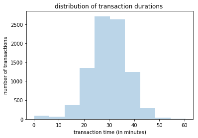

```python
plt.hist(df['duration'], alpha=0.3)
plt.title('distribution of transaction durations ')
plt.xlabel('transaction time (in minutes)')
plt.ylabel('number of transactions');
```

Interestingly, all transactions take fewer than 61 minutes to complete.  
They are split almost evenly: 50% of transactions take fewer than 30 minutes and 50% between 30 and 61 minutes.

#### Clean

No cleaning is necessary. After reviewing the dataset both `visually` ( opening the `.csv` file using Excel) and `programmatically` (using pandas funtions as you can see above) the data is considered clean and ready to analyze.

### Exploratory Data Analysis

`1.` There are two columns (`day`,`fraud`) that are **categorical** variables and need to be changed to [dummy variables](https://www.geeksforgeeks.org/how-to-create-dummy-variables-in-python-with-pandas/) using 0, 1 encodings.  
Furthermore, one dummy column from each **categorical** variable will need to be dropped (from the model, not the dataframe) for the solution to be stable and the results from Python to be reliable.  
Finally, an `intercept` column with a value of `1` will be inserted into the dataframe, so that the model will work.

```python
df_clean = df.copy()
```

```python
df_clean['intercept']= 1
df_clean[['weekday', 'weekend']] = pd.get_dummies(df_clean['day'])
```

```python
df_clean[['no_fraud', '_fraud_']] = pd.get_dummies(df_clean['fraud'])
```

```python
df_clean = df_clean[['transaction_id', 'duration', 'day', 'weekday', 'weekend', 'fraud'\
        ,'_fraud_', 'no_fraud', 'intercept']]
df_clean.sample()
```

|  | transaction_id | duration | day | weekday | weekend | fraud | _fraud_ | no_fraud | intercept |
| --- | --- | --- | --- | --- | --- | --- | --- | --- | --- |
| 6871 | 34098 | 29.548653 | weekend | 0 | 1 | False | 0 | 1 | 1 |

The logistic regression model:  
`1` Use the `Logit()` function to create the logistic model  
`2` `Fit` the model to the data  
`3` View and interpret the `summary` results

```python
model = sm.Logit(df_clean['_fraud_'], df_clean[['intercept', 'duration', 'weekday']])
result = model.fit()
result.summary2()
```

```
Optimization terminated successfully.
         Current function value: inf
         Iterations 16
```

| Model: | Logit | No. Iterations: | 16.0000 |
| --- | --- | --- | --- |
| Dependent Variable: | _fraud_ | Pseudo R-squared: | nan |
| Date: | 2022-05-25 09:03 | AIC: | inf |
| No. Observations: | 8793 | BIC: | inf |
| Df Model: | 2 | Log-Likelihood: | -inf |
| Df Residuals: | 8790 | LL-Null: | -inf |
| Converged: | 1.0000 | Scale: | 1.0000 |

|  | Coef. | Std.Err. | z | P>\|z\| | [0.025 | 0.975] |
| --- | --- | --- | --- | --- | --- | --- |
| intercept | 9.8709 | 1.9438 | 5.0783 | 0.0000 | 6.0613 | 13.6806 |
| duration | -1.4637 | 0.2905 | -5.0389 | 0.0000 | -2.0331 | -0.8944 |
| weekday | 2.5465 | 0.9043 | 2.8160 | 0.0049 | 0.7741 | 4.3188 |

### Analyzing - Understanding the results

`1` At the bottom of the summary table above, there is the `p-value` for the duration and weekday coefficients.  
The `p-value` in both cases is either zero or very small (see below).  
This means that both duration and weekday are `statistically important` and should be included , when analyzing the possibility of a transaction fraud.

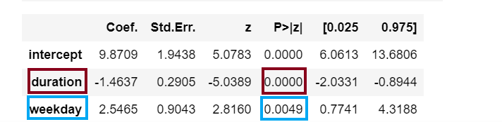

```python
Image("lg1.png", width=550, height=550)
```

`2` In order to interpret the coefficients , their values need to be exponentiated:

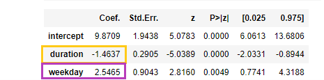

```python
Image("lg2.png", width=550, height=550)
```

```python
np.exp(-1.4637), np.exp(2.5465)
```

```
(0.23137858821179411, 12.762357271496972)
```

Each of these resulting values ( `duration`:0.23, `weekday`:12.7) is the multiplicative change in the odds.

### **Answer (α):**

#### On weekdays, the chance of fraud is **12.7 times more likely** than in the weekends, when keeping the duration of the transaction constant.

Thus, for transactions of same duration, they are much more likely to be a fraud on weekdays (12.7 times more likely!) than in the weekend.

Let's now look at `duration`; Due to the exponentiated value of `duration`< 1 , it is useful to calculate its reciprocal value and then intepret the result:

```python
1/np.exp(-1.4637)
```

```
4.3219210892783329
```

### **Answer (β):**

#### For **each minute less** spent on the transaction, the chance on fraud is **4.3 times more likely**, when holding the day of the week the same ( weekday or weekend transactions).

Thus, a 28-minute transaction on a weekend is 4.3 times more likely to be a fraud, compared to a 29-minute weekend transaction.  
Likewise, a 15-minute transaction on a weekday is 4.3 times more likely to be a fraud, compared to a 16-minute weekday transaction.